# Titanic EDA

The goal of this EDA is to determine what features are likely to have contributed to Titanic passenger's survival.

### 1. Import Libraries

```python
import pandas as pd
import numpy as np
import matplotlib.pyplot as plt
import seaborn as sns
%matplotlib inline
```

```python
df = pd.read_csv('train.csv')
```

#### 1.1 Data Structure

```python
df.head()
```

|  | PassengerId | Survived | Pclass | Name | Sex | Age | SibSp | Parch | Ticket | Fare | Cabin | Embarked |
| --- | --- | --- | --- | --- | --- | --- | --- | --- | --- | --- | --- | --- |
| 0 | 1 | 0 | 3 | Braund, Mr. Owen Harris | male | 22.0 | 1 | 0 | A/5 21171 | 7.2500 | NaN | S |
| 1 | 2 | 1 | 1 | Cumings, Mrs. John Bradley (Florence Briggs Th... | female | 38.0 | 1 | 0 | PC 17599 | 71.2833 | C85 | C |
| 2 | 3 | 1 | 3 | Heikkinen, Miss. Laina | female | 26.0 | 0 | 0 | STON/O2. 3101282 | 7.9250 | NaN | S |
| 3 | 4 | 1 | 1 | Futrelle, Mrs. Jacques Heath (Lily May Peel) | female | 35.0 | 1 | 0 | 113803 | 53.1000 | C123 | S |
| 4 | 5 | 0 | 3 | Allen, Mr. William Henry | male | 35.0 | 0 | 0 | 373450 | 8.0500 | NaN | S |

```python
df.info()
```

```
<class 'pandas.core.frame.DataFrame'>
RangeIndex: 891 entries, 0 to 890
Data columns (total 12 columns):
 #   Column       Non-Null Count  Dtype
---  ------       --------------  -----
 0   PassengerId  891 non-null    int64
 1   Survived     891 non-null    int64
 2   Pclass       891 non-null    int64
 3   Name         891 non-null    object
 4   Sex          891 non-null    object
 5   Age          714 non-null    float64
 6   SibSp        891 non-null    int64
 7   Parch        891 non-null    int64
 8   Ticket       891 non-null    object
 9   Fare         891 non-null    float64
 10  Cabin        204 non-null    object
 11  Embarked     889 non-null    object
dtypes: float64(2), int64(5), object(5)
memory usage: 83.7+ KB
```

```python
df.shape
# there are 891 records with 12 observations
```

```
(891, 12)
```

```python
# checking to see which columns can be converted to categorical
# if unique count is less than 10, those should be converted
df.nunique()
```

```
PassengerId    891
Survived         2
Pclass           3
Name           891
Sex              2
Age             88
SibSp            7
Parch            7
Ticket         681
Fare           248
Cabin          147
Embarked         3
dtype: int64
```

Converting Survived(2 unique values), Pclass(3 unique values), Sex(2 unique values), SibSp(7 unique values), Parch(7 unique values), Embarked(3 unique values) to categorical to facilitate better analysis and also for memory efficiency

```python
df['Survived'] = df['Survived'].astype('category')
df['Pclass'] = df['Pclass'].astype('category')
df['Sex'] = df['Sex'].astype('category')
df['SibSp'] = df['SibSp'].astype('category')
df['Parch'] = df['Parch'].astype('category')
df['Embarked'] = df['Embarked'].astype('category')
```

```python
df.info()
```

```
<class 'pandas.core.frame.DataFrame'>
RangeIndex: 891 entries, 0 to 890
Data columns (total 12 columns):
 #   Column       Non-Null Count  Dtype
---  ------       --------------  -----
 0   PassengerId  891 non-null    int64
 1   Survived     891 non-null    category
 2   Pclass       891 non-null    category
 3   Name         891 non-null    object
 4   Sex          891 non-null    category
 5   Age          714 non-null    float64
 6   SibSp        891 non-null    category
 7   Parch        891 non-null    category
 8   Ticket       891 non-null    object
 9   Fare         891 non-null    float64
 10  Cabin        204 non-null    object
 11  Embarked     889 non-null    category
dtypes: category(6), float64(2), int64(1), object(3)
memory usage: 48.3+ KB
```

### 2. Exploration and Data cleaning

**Survived** is Target/Dependent Variable - Following analysis is to understand the effect of other variable(s) on Survived variable.

- **PassengerId(numerical)** - Unique Id assigned to each passenger
- **Survived(categorical)** - 0 = No, 1 = Yes.
- **Pclass(categorical)** - Passenger Class - 1, 2, 3
- **Name(object)** - Passenger Name
- **Sex(categorical)** - Passenger Sex
- **Age(numerical)** - Passenger Age
- **SibSp(categorical)** - Number of Siblings/Spouses on board
- **Parch(categorical)** - Number of Parents/Children on board
- **Ticket(object)** - Ticket number
- **Fare(numerical)** - Ticket price
- **Cabin(object)** - Cabin number
- **Embarked(categorical)** - Stations from where a Passenger embarked from  
  C - Cherbourg S - Southhampton Q - Queenstown

```python
# Describes non-numerical column data
df.describe(include=['object'])
```

|  | Name | Ticket | Cabin |
| --- | --- | --- | --- |
| count | 891 | 891 | 204 |
| unique | 891 | 681 | 147 |
| top | Braund, Mr. Owen Harris | 347082 | B96 B98 |
| freq | 1 | 7 | 4 |

```python
# Describes Numerical column data
df.describe(include=['number'])
```

|  | PassengerId | Age | Fare |
| --- | --- | --- | --- |
| count | 891.000000 | 714.000000 | 891.000000 |
| mean | 446.000000 | 29.699118 | 32.204208 |
| std | 257.353842 | 14.526497 | 49.693429 |
| min | 1.000000 | 0.420000 | 0.000000 |
| 25% | 223.500000 | 20.125000 | 7.910400 |
| 50% | 446.000000 | 28.000000 | 14.454200 |
| 75% | 668.500000 | 38.000000 | 31.000000 |
| max | 891.000000 | 80.000000 | 512.329200 |

#### 2.1 Missing values

```python
df.isnull().sum()
```

```
PassengerId      0
Survived         0
Pclass           0
Name             0
Sex              0
Age            177
SibSp            0
Parch            0
Ticket           0
Fare             0
Cabin          687
Embarked         2
dtype: int64
```

```python
print(df['Age'].isnull().sum()/len(df['Age']))
print(df['Cabin'].isna().sum()/len(df['Cabin']))
print(df['Embarked'].isna().sum()/len(df['Embarked']))
```

```
0.19865319865319866
0.7710437710437711
0.002244668911335578
```

> 1. Data only has 714(891-177) values for Age column. About 20% Age values are missing
> 2. Data only has 204(891-687) values for Cabin column. About 77% Cabin values are missing. This column will be dropped.
> 3. Missing Embarked rows will be filled with the mode of the Embarked value.

```python
df.drop(columns='Cabin',inplace=True)
```

```python
df['Embarked'].fillna(df['Embarked'].mode()[0], inplace=True)
```

### 3. Univariate Analysis

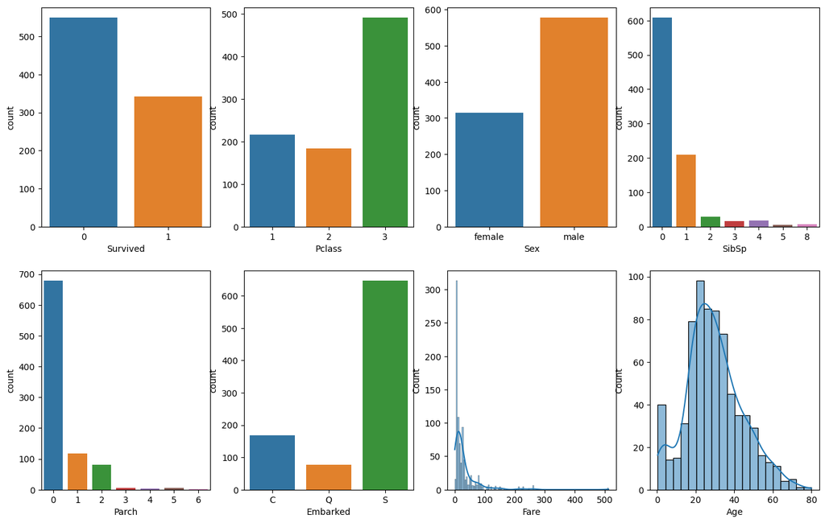

```python
fig, axes = plt.subplots(2, 4, figsize=(16, 10))
sns.countplot(x='Survived', data=df,ax=axes[0,0]) #categorical
sns.countplot(x='Pclass', data=df,ax=axes[0,1]) #categorical
sns.countplot(x='Sex',data=df,ax=axes[0,2]) #categorical
sns.countplot(x='Embarked',data=df,ax=axes[1,1]) #categorical
sns.countplot(x='SibSp',data=df,ax=axes[0,3]) #categorical
sns.countplot(x='Parch',data=df,ax=axes[1,0]) #categorical

sns.histplot(df['Age'].dropna(),kde=True,ax=axes[1,3]) #numerical
sns.histplot(df['Fare'], kde=True,ax=axes[1,2]) #numerical
plt.show()
```

```python
df['Name']
```

```
0                                Braund, Mr. Owen Harris
1      Cumings, Mrs. John Bradley (Florence Briggs Th...
2                                 Heikkinen, Miss. Laina
3           Futrelle, Mrs. Jacques Heath (Lily May Peel)
4                               Allen, Mr. William Henry
                             ...
886                                Montvila, Rev. Juozas
887                         Graham, Miss. Margaret Edith
888             Johnston, Miss. Catherine Helen "Carrie"
889                                Behr, Mr. Karl Howell
890                                  Dooley, Mr. Patrick
Name: Name, Length: 891, dtype: object
```

```python
df['Ticket'].value_counts().sort_values(ascending=False)
```

```
Ticket
347082              7
1601                7
CA. 2343            7
3101295             6
CA 2144             6
                   ..
2683                1
SOTON/O2 3101287    1
11774               1
392092              1
370376              1
Name: count, Length: 681, dtype: int64
```

```python
df[df['Ticket']=='347082']
```

|  | PassengerId | Survived | Pclass | Name | Sex | Age | SibSp | Parch | Ticket | Fare | Embarked |
| --- | --- | --- | --- | --- | --- | --- | --- | --- | --- | --- | --- |
| 13 | 14 | 0 | 3 | Andersson, Mr. Anders Johan | male | 39.0 | 1 | 5 | 347082 | 31.275 | S |
| 119 | 120 | 0 | 3 | Andersson, Miss. Ellis Anna Maria | female | 2.0 | 4 | 2 | 347082 | 31.275 | S |
| 541 | 542 | 0 | 3 | Andersson, Miss. Ingeborg Constanzia | female | 9.0 | 4 | 2 | 347082 | 31.275 | S |
| 542 | 543 | 0 | 3 | Andersson, Miss. Sigrid Elisabeth | female | 11.0 | 4 | 2 | 347082 | 31.275 | S |
| 610 | 611 | 0 | 3 | Andersson, Mrs. Anders Johan (Alfrida Konstant... | female | 39.0 | 1 | 5 | 347082 | 31.275 | S |
| 813 | 814 | 0 | 3 | Andersson, Miss. Ebba Iris Alfrida | female | 6.0 | 4 | 2 | 347082 | 31.275 | S |
| 850 | 851 | 0 | 3 | Andersson, Master. Sigvard Harald Elias | male | 4.0 | 4 | 2 | 347082 | 31.275 | S |

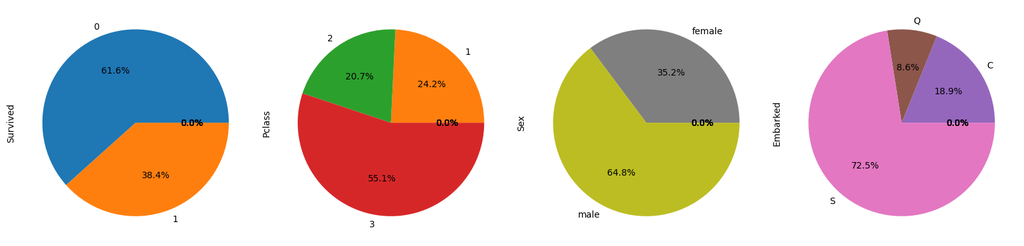

```python
df[['Survived','Pclass','Sex','Embarked']].apply(pd.Series.value_counts).plot.pie(subplots=True,\
            figsize=(16, 10), autopct='%1.1f%%', legend=False)

plt.tight_layout()
plt.show()
```

```python
print("Fare in between $200 and $300",df[(df['Fare']>200) & (df['Fare']<300)].shape[0])
print("Fare greater than $500",df[df['Fare']>500].shape[0])
```

```
Fare in between $200 and $300 17
Fare greater than $500 3
```

#### 3.1 Univariate Analysis Observations

##### Categorical Data Observations

> 1. Survived(Cat.) - Out of 891 passengers, only 38% survived which is 342. More than half(61.6%) the Passengers died. Number of passengers that did not survive is 549.
> 2. PClass(Cat.) - Most passengers were in Pclass 3. More passengers travelled in Pclass 1 than in 2.
> 3. Sex(Cat.) - There are more Males passengers than Female passengers
> 4. SibSp(Cat.) - There are more single people traveling than in families. The SibSp and Parch are pointing to a family size which will be analyzed further.
> 5. Parch(Cat.) - There are more single people traveling than in families. The SibSp and Parch are pointing to a family size which will be analyzed further.
> 6. Embarked(Cat.) - There are more passengers that embarked from Southhampton as compared to Cherbourg or Queenstown

##### Numerical Data Observations

> 7. Age(Num.) - Most passengers are in the age group between 20 - 40. Almost normally distributed. There are a few outliers.
> 8. Fare(Num.) - Not normally distributed, highly skewed. Most passengers are paying less compared to few passengers that have paid a high price. Data is right skewed. There are a lot of outliers. There are passenger(s) that have paid more than $500. A family is assigned same ticket and the fare is same. Fare will need to be calculated per person instead of by family size as determined by SibSp and Parch values.

##### Mixed Data Obervations

> 9. Name - Name column contains Passenger's surname, title and first name. This needs to be analyzed further.
> 10. Ticket - Ticket number is same for the family members.

>     > a. Surname of passengers with the same ticket number is same and it should be mostly same.  
>     > b. The Fare price is also same for all passengers and this would need to be analyzed further.  
>     > c. The SibSp and Parch are pointing to a family size which will need to be analyzed further.
> 11. Cabin - There are 77% missing values in this column.

#### 3.2 Feature Engineering

#### 3.2.1 Family Type - SibSp, Parch columns

```python
df[df['Ticket']=='347082']
```

|  | PassengerId | Survived | Pclass | Name | Sex | Age | SibSp | Parch | Ticket | Fare | Embarked |
| --- | --- | --- | --- | --- | --- | --- | --- | --- | --- | --- | --- |
| 13 | 14 | 0 | 3 | Andersson, Mr. Anders Johan | male | 39.0 | 1 | 5 | 347082 | 31.275 | S |
| 119 | 120 | 0 | 3 | Andersson, Miss. Ellis Anna Maria | female | 2.0 | 4 | 2 | 347082 | 31.275 | S |
| 541 | 542 | 0 | 3 | Andersson, Miss. Ingeborg Constanzia | female | 9.0 | 4 | 2 | 347082 | 31.275 | S |
| 542 | 543 | 0 | 3 | Andersson, Miss. Sigrid Elisabeth | female | 11.0 | 4 | 2 | 347082 | 31.275 | S |
| 610 | 611 | 0 | 3 | Andersson, Mrs. Anders Johan (Alfrida Konstant... | female | 39.0 | 1 | 5 | 347082 | 31.275 | S |
| 813 | 814 | 0 | 3 | Andersson, Miss. Ebba Iris Alfrida | female | 6.0 | 4 | 2 | 347082 | 31.275 | S |
| 850 | 851 | 0 | 3 | Andersson, Master. Sigvard Harald Elias | male | 4.0 | 4 | 2 | 347082 | 31.275 | S |

Observations so far  
Last name of Passengers with ticket 347082 are a family with last name = "Andersson" and a family_size of 7.

1. A new column called family_size will be created which is made up of SibSp, Parch plus one (one for the person who is buying the ticket). family_size=SibSp+Parch+1
2. A new column called family_type will be created which will show the family type(alone(1), small(2-4), large (>5)). This will help with future predictions of Survived variable

```python
df['family_size'] = df['SibSp'].astype(int) + df['Parch'].astype(int) + 1
```

```python
# family_type
# 1 -> alone
# 2-4 -> small
# >5 -> large

def transform_family_size(num):

  if num == 1:
    return 'alone'
  elif num>1 and num <5:
    return "small"
  else:
    return "large"
```

```python
df['family_type'] = df['family_size'].apply(transform_family_size)
```

#### 3.2.2 Fare calculation per individual

A new column called indvidual_fare will be created based on Fare and the family_size value calculated earlier.

```python
df['individual_fare']= df['Fare']/(df['family_size'])
```

```python
df[df['Ticket'] == '347082']
```

|  | PassengerId | Survived | Pclass | Name | Sex | Age | SibSp | Parch | Ticket | Fare | Embarked | family_size | family_type | individual_fare |
| --- | --- | --- | --- | --- | --- | --- | --- | --- | --- | --- | --- | --- | --- | --- |
| 13 | 14 | 0 | 3 | Andersson, Mr. Anders Johan | male | 39.0 | 1 | 5 | 347082 | 31.275 | S | 7 | large | 4.467857 |
| 119 | 120 | 0 | 3 | Andersson, Miss. Ellis Anna Maria | female | 2.0 | 4 | 2 | 347082 | 31.275 | S | 7 | large | 4.467857 |
| 541 | 542 | 0 | 3 | Andersson, Miss. Ingeborg Constanzia | female | 9.0 | 4 | 2 | 347082 | 31.275 | S | 7 | large | 4.467857 |
| 542 | 543 | 0 | 3 | Andersson, Miss. Sigrid Elisabeth | female | 11.0 | 4 | 2 | 347082 | 31.275 | S | 7 | large | 4.467857 |
| 610 | 611 | 0 | 3 | Andersson, Mrs. Anders Johan (Alfrida Konstant... | female | 39.0 | 1 | 5 | 347082 | 31.275 | S | 7 | large | 4.467857 |
| 813 | 814 | 0 | 3 | Andersson, Miss. Ebba Iris Alfrida | female | 6.0 | 4 | 2 | 347082 | 31.275 | S | 7 | large | 4.467857 |
| 850 | 851 | 0 | 3 | Andersson, Master. Sigvard Harald Elias | male | 4.0 | 4 | 2 | 347082 | 31.275 | S | 7 | large | 4.467857 |

#### 3.2.3 Name - title column

Analyze the impact of Title on Survived variable.

```python
df['title'] = df['Name'].str.split(',').str.get(1).str.strip().str.split(' ').str.get(0)
```

```python
df['title'].value_counts()
```

```
title
Mr.          517
Miss.        182
Mrs.         125
Master.       40
Dr.            7
Rev.           6
Mlle.          2
Major.         2
Col.           2
the            1
Capt.          1
Ms.            1
Sir.           1
Lady.          1
Mme.           1
Don.           1
Jonkheer.      1
Name: count, dtype: int64
```

```python
df['title'] = df['title'].str.replace(r'Jonkheer\.|Don\.|Sir\.|Dona\.|Lady\.', 'Royal', regex=True)
df['title'] = df['title'].str.replace(r'Capt\.|Col\.|Major\.|Dr\.|Rev\.', 'Officer', regex=True)
```

#### 3.2.4 Age column

Impute Pclass mean values for missing Age - Get the mean age of each Pclass and use that for missing Age value

```python
df['Age'].isnull().sum()
```

```
177
```

```python
df.head(2)
```

|  | PassengerId | Survived | Pclass | Name | Sex | Age | SibSp | Parch | Ticket | Fare | Embarked | family_size | family_type | individual_fare | title |
| --- | --- | --- | --- | --- | --- | --- | --- | --- | --- | --- | --- | --- | --- | --- | --- |
| 0 | 1 | 0 | 3 | Braund, Mr. Owen Harris | male | 22.0 | 1 | 0 | A/5 21171 | 7.2500 | S | 2 | small | 3.62500 | Mr. |
| 1 | 2 | 1 | 1 | Cumings, Mrs. John Bradley (Florence Briggs Th... | female | 38.0 | 1 | 0 | PC 17599 | 71.2833 | C | 2 | small | 35.64165 | Mrs. |

```python
def fill_missing_age(row):
    pclass = row['Pclass']
    mean_age_pclass = df.query('Pclass==@pclass')['Age'].mean()
    if pd.isnull(row['Age']):
        return mean_age_pclass
    else:
        return row['Age']

df['Age'] = df.apply(fill_missing_age, axis=1)
```

```python
df['Age'].isnull().sum()
```

```
0
```

### 4. Bivariate Analysis

Goal - Based on above Univariate analysis, the goal of further analysis in this notebook is to determine which features affected the Survived value to a signinicant level.

#### 4.1 Categorical vs Categorical

Survived with Pclass, Embarked, Sex, family_type

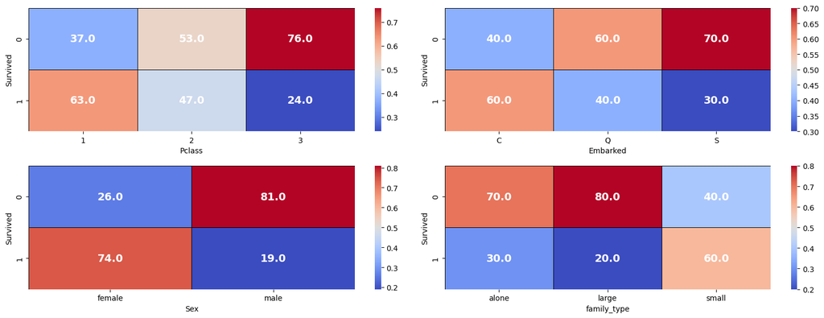

```python
# Function to add annotations
def add_annotations(crosstab, ax):
    for i, row in enumerate(crosstab.index):
        for j, col in enumerate(crosstab.columns):
            value = crosstab.iloc[i, j]
            ax.text(j + 0.5, i + 0.5, f'{value}', ha='center', va='center',
                    fontsize=14, color='white', weight='bold')

crosstab1 = pd.crosstab(df['Survived'], df['Pclass'], normalize='columns').round(2)
crosstab2 = pd.crosstab(df['Survived'], df['Embarked'], normalize='columns').round(1)
crosstab3 = pd.crosstab(df['Survived'], df['Sex'],normalize='columns').round(2)
crosstab4 = pd.crosstab(df['Survived'], df['family_type'],normalize='columns').round(1)
fig,axes = plt.subplots(2,2, figsize=(16,6))

sns.heatmap(crosstab1, annot=False, cmap='coolwarm', ax=axes[0,0], cbar=True,\
            linewidths=0.5, linecolor='black')

sns.heatmap(crosstab2, annot=False, cmap='coolwarm', ax=axes[0,1], cbar=True,\
            linewidths=0.5, linecolor='black')

sns.heatmap(crosstab3, annot=False, cmap='coolwarm', ax=axes[1,0], cbar=True,\
            linewidths=0.5, linecolor='black')

sns.heatmap(crosstab4, annot=False, cmap='coolwarm', ax=axes[1,1], cbar=True,\
            linewidths=0.5, linecolor='black')

# Manually add annotations to ensure visibility
add_annotations(crosstab1*100, axes[0,0])
add_annotations(crosstab2*100, axes[0,1])
add_annotations(crosstab3*100, axes[1,0])
add_annotations(crosstab4*100, axes[1,1])

plt.tight_layout()
plt.show()
```

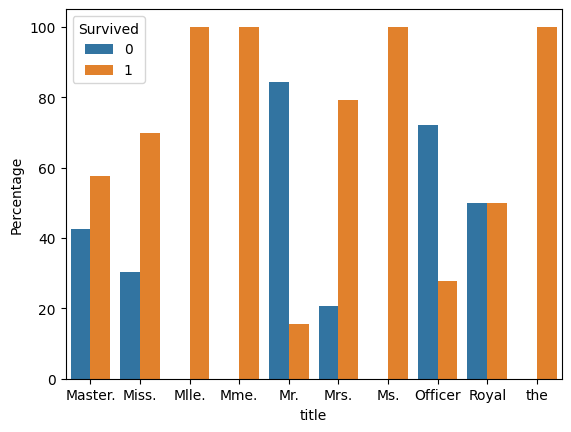

```python
crosstab_title = pd.crosstab(df['Survived'],df['title'],normalize='columns')*100
crosstab_long = crosstab_title.reset_index().melt(id_vars='Survived', value_vars=crosstab_title.columns, var_name='title', value_name='Percentage')

sns.barplot(data=crosstab_long, x='title', y='Percentage', hue='Survived')
plt.show()
```

```python
df.groupby('Sex')['title'].value_counts().reset_index(name='Count').query('Count>0')
```

|  | Sex | title | Count |
| --- | --- | --- | --- |
| 0 | female | Miss. | 182 |
| 1 | female | Mrs. | 125 |
| 2 | female | Mlle. | 2 |
| 3 | female | Mme. | 1 |
| 4 | female | Ms. | 1 |
| 5 | female | Officer | 1 |
| 6 | female | Royal | 1 |
| 7 | female | the | 1 |
| 10 | male | Mr. | 517 |
| 11 | male | Master. | 40 |
| 12 | male | Officer | 17 |
| 13 | male | Royal | 3 |

#### 4.1.1 Observations - Categorical vs Categorical

> 1. Pclass - Passengers in Pclass 1 have the highest survival rate(63%). Passengers in Pclass 3 had the most deaths(76%).
> 2. Sex - Females(74%) survived more than Males.
> 3. Embarked - Passengers that embarked from Chergourg(55%) had better survival rate compared to the passengers from Southhampton(34%) and Queenstown(39%).
> 4. Family_type - Passengers belonging to small(58%) family_type survived the most. Supporting the assumption that families with small children were given priority and rescued first. Passengers belonging to Single(30%) and Large(20%) family_type had the lowest survival rate. This is an interesting observation - **Mid size families had higher survival chance.**
> 5. Title - Passengers with titles - Master, Miss, Mlle, Mme, Mrs, Ms and the survived the most, further supporting the Sex criteria above. Titles such as Mr, Officer who were mostly males did not survive.

Assumptions 1 - Based on these 3 observations, following assumptions came up

> 1. Passengers that embarked from Cherbourg had more female passengers or they had more number of Pclass passengers.
> 2. Since Pclass 1 passengers survived the most, and also most Cherbourg passengers survived, is there a correlation between these two?  
>    a. Is it possible that most Pclass 1 passengers embarked from Cherbourg.  
>    b. Is it possible that most female passengers embarked from Cherbourg.

```python
print(pd.crosstab(df['Pclass'], df['Embarked'], normalize='columns')*100)
print(pd.crosstab(df['Sex'], df['Embarked'], normalize='columns')*100)
```

```
Embarked          C          Q          S
Pclass
1         50.595238   2.597403  19.969040
2         10.119048   3.896104  25.386997
3         39.285714  93.506494  54.643963
Embarked          C          Q          S
Sex
female    43.452381  46.753247  31.733746
male      56.547619  53.246753  68.266254
```

#### 4.2 Categorical vs Numerical

Survived vs Age and Survived vs individual_fare

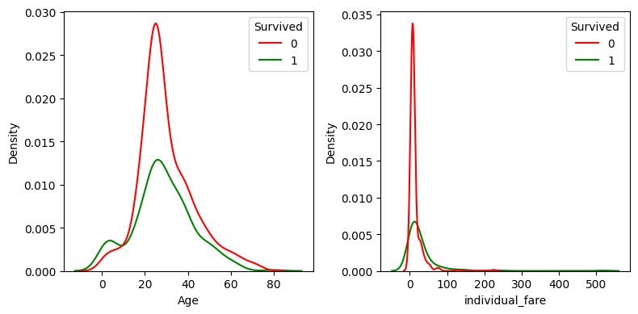

```python
fig, axes = plt.subplots(nrows=1, ncols=2, figsize=(8, 4))
sns.kdeplot(data=df, x='Age', hue='Survived', ax=axes[0], palette={0: 'red', 1: 'green'})
sns.kdeplot(data=df, x='individual_fare', hue='Survived', ax=axes[1], palette={0: 'red', 1: 'green'})

plt.tight_layout()
plt.show()
```

```python
print('Youngest person survived ', df.query('Survived == 1')['Age'].min())
print('Oldest person survived ', df.query('Survived == 1')['Age'].max())
print('Mean age that survived ', df.query('Survived == 1')['Age'].mean())

total_infants_count = df.query('Age < 5')['PassengerId'].count()
survived_infants_count = df.query('Survived == 1 & Age < 5')['PassengerId'].count()
print('Infants survivability rate ', (survived_infants_count/total_infants_count)*100)

total_midage_count = df.query('Age > 20 and Age <= 45')['PassengerId'].count()
death_midage_count = df.query('Survived == 0 and Age > 20 and Age <= 45')['PassengerId'].count()
print('Mid age death rate ', (death_midage_count/total_midage_count)*100)

over_sixty_count = df.query('Age > 60')['PassengerId'].count()
death_oversixty_count = df.query('Survived == 0 and Age > 60')['PassengerId'].count()
print('Over 60 death rate ', (death_oversixty_count/over_sixty_count)*100)
```

```
Youngest person survived  0.42
Oldest person survived  80.0
Mean age that survived  28.44804024180339
Infants survivability rate  67.5
Mid age death rate  63.54679802955665
Over 60 death rate  77.27272727272727
```

```python
avg_fare = df['individual_fare'].mean()
print('Average Fare ', avg_fare)
# number of passengers that paid more than the avg_fare and their survival rate
total_over_avgfare = df.query('individual_fare > @avg_fare')['PassengerId'].count()
survived_over_avgfare = df.query('Survived == 1 and individual_fare > @avg_fare')['PassengerId'].count()
print('Survival rate of above avg fare passengers ', (survived_over_avgfare/total_over_avgfare)*100)
```

```
Average Fare  19.916375111917638
Survival rate of above avg fare passengers  60.61946902654868
```

#### 4.2.1 Observations and Conclusions - Categorical vs Numerical

> Age  
> Age observations suggest that infants were given priority and rescued first.
> 2. Survived and individual_fare -  
>    a. Passengers that paid more have a higher rate of surviving. And this was previously concluded by Pclass and Survived analysis.

> individual_fare  
> About 60% of Passengers that paid over the average fares survived.

Assumptions to check in Multivariate Analysis

> a. Is it possible that the passengers that survived in the age group of 20-45 were in Pclass 1?  
> b. Is there a correlation between Age and family_type. Is it possible that passengers who survived most were from a family with certain number of members.

#### 4.3 Numerical vs Numerical

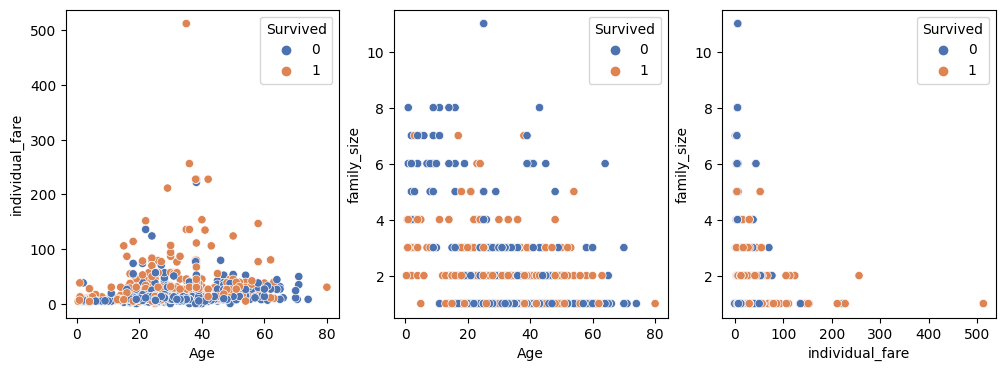

```python
fig, axes = plt.subplots(1,3, figsize=(12, 4))
sns.scatterplot(x='Age', y='individual_fare', hue='Survived', \
    data=df, palette='deep', ax=axes[0])
sns.scatterplot(x='Age', y='family_size', hue='Survived', \
    data=df, palette='deep', ax=axes[1])
sns.scatterplot(x='individual_fare', y='family_size', hue='Survived', \
    data=df, palette='deep', ax=axes[2])
plt.show()
```

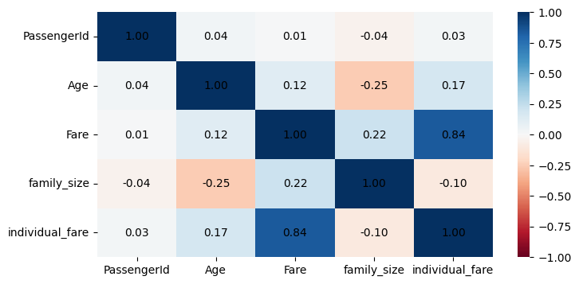

```python
plt.figure(figsize=(8,4))
corr = df.corr(numeric_only=True)

ax = sns.heatmap(corr, cmap='RdBu', vmin=-1,vmax=1, annot=False, robust=True)
for i in range(corr.shape[0]):
    for j in range(corr.shape[1]):
        text = ax.text(j + 0.5, i + 0.5, f'{corr.iloc[i, j]:.2f}',
                       ha='center', va='center',
                       fontsize=10, color='black')
plt.show()
```

##### 4.3.1 Conclusions

> 1. Age and individual_fare - individual_fare was a column that was feature engineered based on fare and family_size. Passengers who paid higher individual_fare survived more. This has been already analyzed. Passengers that paid the most for their fares appear to be in the age group of 30 - 40.  
>    Age and individual_fare are weakly positively correlated. As Age increased, the individual_fare also increased slightly. Assumption - These could be passengers traveling in Pclass 1.
> 2. Age and family_size - Passengers in the family_size of 2-4 appear to survive more. Irrespective of Age, passengers in smaller family_size of 2 had higher survival chance. Passengers that had young children below the age of 15 also had higher survival chance as previously concluded.  
>    Age and family_size are negatively correlated. As age increases, the family_size decreases.
> 3. individual_fare and family_size - As individual_fare increases there is a decrease in family_size. There is a negative correlation between individual_fare and family_size.

### 5. Multivariate Analysis

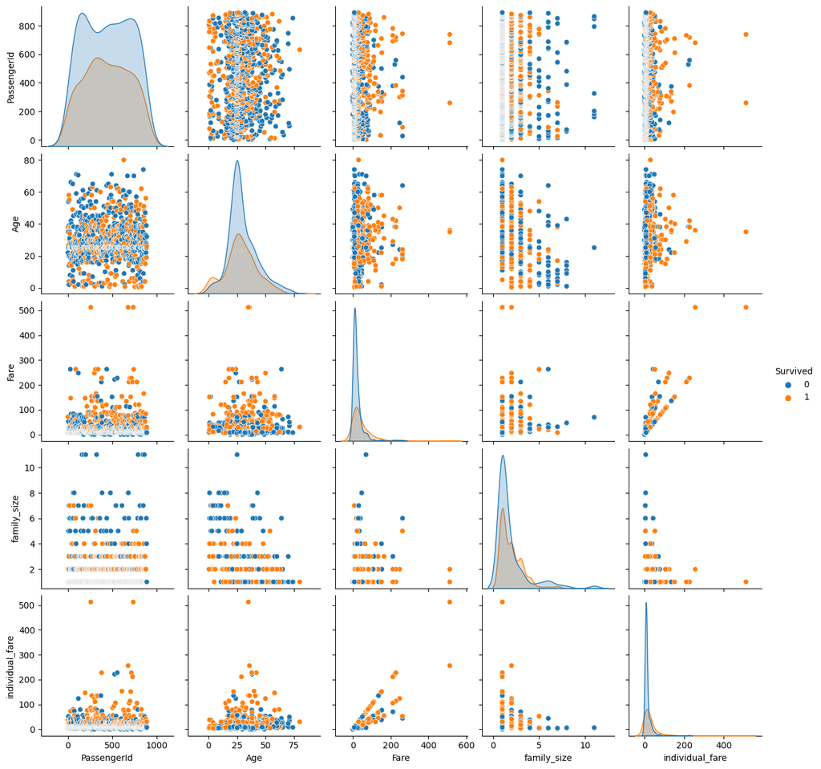

```python
sns.pairplot(df, hue='Survived')
plt.show()
```

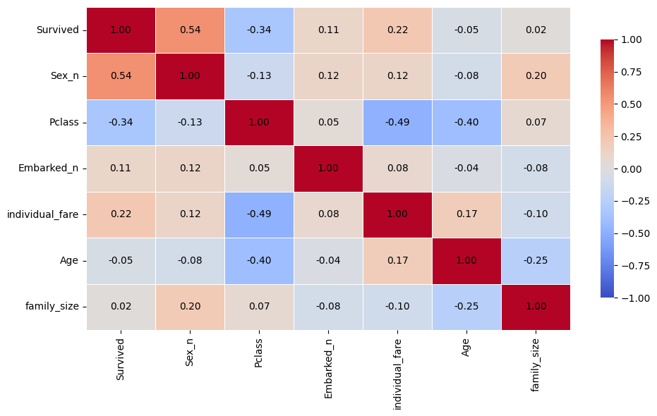

```python
df["Sex_n"]  = pd.factorize(df["Sex"])[0]
df["Embarked_n"] = pd.factorize(df["Embarked"])[0]

fig, axes = plt.subplots(figsize = (10, 6))
corr_matrix = df[["Survived","Sex_n", "Pclass", "Embarked_n", \
    "individual_fare", "Age", "family_size"]].corr()

heatmap = sns.heatmap(corr_matrix, cmap='coolwarm', annot = False, \
    vmin=-1, vmax=1, linewidths=0.5, cbar_kws={"shrink": 0.8})

for i in range(corr_matrix.shape[0]):
    for j in range(corr_matrix.shape[1]):
        value = corr_matrix.iloc[i, j]
        text = f"{corr_matrix.iloc[i, j]:.2f}"
        axes.text(j + 0.5, i + 0.5, text, ha='center', va='center', color='black', fontsize=10)

plt.tight_layout()
plt.show()
```